# Effects of tool use and perturbation during motor adaptation on hand localization in immersive virtual reality

Maryum Khan

Load packages

# Reach to Target

## Hand (Experiment 1)

### 30 degrees

```r
hand_30 <- read.csv("hand_30.csv")
#ppid from int to chr
hand_30$ppid <- as.character(hand_30$ppid)
#calculate angular deviation
deviation <- hand_30$cursor_3cm_out_angle - hand_30$target_angle
hand_30$deviation <- hand_30$cursor_3cm_out_angle - hand_30$target_angle

##Aligned session
#Filter last 3 blocks of aligned hand reaches and add summary statistics
aligned_30 <- hand_30 %>%
  filter(type=='aligned', block_num > 19)%>%
  mutate(type = 'aligned_30') %>%
  group_by(experiment, type, trial_num)%>%
  summarise(aligned_mean=mean(deviation, na.rm = TRUE),
            reaches_median=median(deviation, na.rm = TRUE),
            sd_err = sd(deviation, na.rm = TRUE),
            n=n(),.groups = 'drop') %>%
  mutate(lower_ci = reaches_median - qt(1 - (0.05/2), n - 1) * (sd_err / sqrt(n)),
         upper_ci = reaches_median + qt(1 - (0.05/2), n - 1) * (sd_err / sqrt(n)))

#reorder the aligned trials so they appear in sequence
aligned_30$sequential_trials <- 1:(nrow(aligned_30))

##Rotated session
#Filter first 100 rotated hand reaches and add summary statistics
#Deviation = cursor_3cm_out_angle - target_angle
rotated_30 <- hand_30 %>%
  filter(type=='rotated', block_num < 30)%>%
  mutate(type = 'rotated_30') %>%
  group_by(experiment, type, trial_num)%>%
  summarise(rotated_mean=mean(deviation, na.rm = TRUE),
            reaches_median=median(deviation, na.rm = TRUE),
            sd_err = sd(deviation, na.rm = TRUE),
            n=n(),.groups = 'drop') %>%
  mutate(lower_ci = reaches_median - qt(1 - (0.05/2), n - 1) * (sd_err / sqrt(n)),
         upper_ci = reaches_median + qt(1 - (0.05/2), n - 1) * (sd_err / sqrt(n)))

# Re-number the trial numbers starting from 1
rotated_30$sequential_trials <- 1:(nrow(rotated_30))
rotated_30$sequential_trials <- rotated_30$sequential_trials + 26
```

### 60 degrees

```r
hand_60 <- read.csv("hand_60.csv")
#ppid from int to chr
hand_60$ppid <- as.character(hand_60$ppid)

##Aligned session
#Filter last 3 blocks of aligned hand reaches and add summary statistics
aligned_hand <- hand_60 %>%
  filter(type=='aligned', block_num > 19)%>%
  mutate(type = 'aligned_hand') %>%
  group_by(experiment, type, trial_num)%>%
  summarise(aligned_mean=mean(deviation, na.rm = TRUE),
            reaches_median=median(deviation, na.rm = TRUE),
            sd_err = sd(deviation, na.rm = TRUE),
            n=n(),.groups = 'drop') %>%
  mutate(lower_ci = reaches_median - qt(1 - (0.05/2), n - 1) * (sd_err / sqrt(n)),
         upper_ci = reaches_median + qt(1 - (0.05/2), n - 1) * (sd_err / sqrt(n)))

#reorder the aligned trials so they appear in sequence
aligned_hand$sequential_trials <- 1:(nrow(aligned_hand))

##Rotated session
#Filter first 100 rotated hand reaches and add summary statistics
#Deviation = cursor_3cm_out_angle - target_angle
rotated_hand <- hand_60 %>%
  filter(type=='rotated', block_num < 30)%>%
  mutate(type = 'rotated_hand') %>%
  group_by(experiment, type, trial_num)%>%
  summarise(rotated_mean=mean(deviation, na.rm = TRUE),
            reaches_median=median(deviation, na.rm = TRUE),
            sd_err = sd(deviation, na.rm = TRUE),
            n=n(),.groups = 'drop') %>%
  mutate(lower_ci = reaches_median - qt(1 - (0.05/2), n - 1) * (sd_err / sqrt(n)),
         upper_ci = reaches_median + qt(1 - (0.05/2), n - 1) * (sd_err / sqrt(n)))

# Re-number the trial numbers starting from 1
rotated_hand$sequential_trials <- 1:(nrow(rotated_hand))
rotated_hand$sequential_trials <- rotated_hand$sequential_trials + 26
```

## Pen (Experiment 2)

Load aligned data

```r
data_toola <- "pen_aligned.csv"
pen_data <- fread(data_toola)
#ppid from int to chr
hand_60$ppid <- as.character(hand_60$ppid)

#Filter last 3 blocks of aligned pen reaches (deviation = pen_3cm_out_angle - target angle )
aligned_pen <- pen_data %>%
  filter(type=='aligned', block_num >43)%>%
  mutate(type = 'aligned_pen') %>%
  group_by(experiment, type, trial_num)%>%
  summarise(aligned_mean=mean(deviation, na.rm = TRUE),
            reaches_median=median(deviation, na.rm = TRUE),
            sd_err = sd(deviation, na.rm = TRUE),
            n=n(),.groups = 'drop') %>%
  mutate(lower_ci = reaches_median - qt(1 - (0.05/2), n - 1) * (sd_err / sqrt(n)),
         upper_ci = reaches_median + qt(1 - (0.05/2), n - 1) * (sd_err / sqrt(n)))

# Create a new variable with consecutive trial numbers
aligned_pen$sequential_trials <- 1:(nrow(aligned_pen))

#ROTATED
#Pen Rotated reaches first 100 trials
data_toolhand <- "pen_rotated.csv"
pen_train <- fread(data_toolhand)
```

Load rotated data

```r
#ROTATED filter first 100 trials
#deviation = pen_3cm_out_angle - target_angle
rotated_pen <- pen_train %>%
  filter(type=='rotated', block_num < 3) %>%
  mutate(type = 'rotated_pen') %>%
  group_by(experiment, type, trial_num)%>%
  summarise(rotated_mean=mean(deviation,na.rm = TRUE),
            reaches_median=median(deviation,na.rm = TRUE),
            sd_err = sd(deviation, na.rm = TRUE),
            n=n(),.groups = 'drop') %>%
  mutate(lower_ci = reaches_median - qt(1 - (0.05/2), n - 1) * (sd_err / sqrt(n)),
         upper_ci = reaches_median + qt(1 - (0.05/2), n - 1) * (sd_err / sqrt(n)))

# Re-number the trial numbers starting from 1
rotated_pen$sequential_trials <- 1:(nrow(rotated_pen))
rotated_pen$sequential_trials <- rotated_pen$sequential_trials + 26

#ROTATED HAND REACHES AFTER TRAINING WITH PEN
data_toolhand <- "pen_rotated.csv"
pen_hand <- fread(data_toolhand)

rotated <- pen_hand %>%
  filter(type=='rotated', block_num > 46)

#rotated_diff <- rotated$hand_3cm_out_angle - rotated$target_angle
rotated$deviation <- rotated$hand_3cm_out_angle - rotated$target_angle
rotated <- rotated %>%
  mutate(type = 'rotated_hand_pen') %>%
  group_by(experiment, type, trial_num)%>%
  summarise(rotated_mean=mean(deviation, na.rm = TRUE),
            reaches_median=median(deviation, na.rm = TRUE),
            sd_err = sd(deviation, na.rm = TRUE),
            n=n(),.groups = 'drop') %>%
  mutate(lower_ci = reaches_median - qt(1 - (0.05/2), n - 1) * (sd_err / sqrt(n)),
         upper_ci = reaches_median + qt(1 - (0.05/2), n - 1) * (sd_err / sqrt(n)))

# Re-number the trial numbers starting from 1
rotated$sequential_trials <- 1:(nrow(rotated))
rotated$sequential_trials <- rotated$sequential_trials + 130
```

## Plot

Now that all variables have been defined, plot learning by combining all trial types

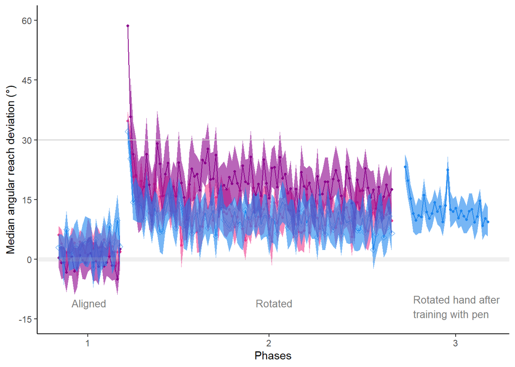

```r
# Combine aligned and rotated datasets into one for ribbon
combined_ribbons <- bind_rows(
  mutate(aligned_hand, source = "hand"),
  mutate(aligned_30, source = "hand"),
  mutate(aligned_pen, source = "pen"),
  mutate(rotated_hand, source = "hand"),
   mutate(rotated_30, source = "hand"),
  mutate(rotated_pen, source = "pen"),
  mutate(rotated, source = "hand")
)

#Plot learning
reaches <- ggplot(combined_ribbons, aes(x = sequential_trials, y = reaches_median,
                                        color = type, fill = type, shape = type)) +
  geom_point() +
  geom_line() +
  geom_ribbon(aes(ymin = lower_ci, ymax = upper_ci), alpha = 0.6, color = NA)

#Change point shape to differentiate between hand and pen trial types and adjust colors
reaches <- reaches +
  scale_shape_manual(values = c("aligned_hand" = 20, "rotated_hand" = 20,
                                "aligned_30" = 20, "rotated_30" = 20,
                                "aligned_pen" = 5, "rotated_pen" = 5, "rotated_hand_pen" = 20))+
  scale_color_manual(values = c("aligned_hand" = "darkmagenta", "aligned_30" = "violetred2", "aligned_pen" = "dodgerblue2",
                                "rotated_hand" = "darkmagenta", "rotated_30" = "violetred2", "rotated_pen" = "dodgerblue2",
                                "rotated_hand_pen" = "dodgerblue2")) +
  scale_fill_manual(values = c("aligned_hand" = "darkmagenta","aligned_30" = "violetred2", "aligned_pen" = "dodgerblue2",
                               "rotated_hand" = "darkmagenta","rotated_30" = "violetred2", "rotated_pen" = "dodgerblue2",
                               "rotated_hand_pen" = "dodgerblue2"))

#Adjust x and y axis and add horizontal lines
reaches <- reaches +
  theme_classic()+
  theme(legend.position = "none")+
  geom_hline(
    yintercept = 30, linewidth = 0.4,
    colour = "#CCCCCC", linetype = "solid"
  )+
  geom_hline(
    yintercept = 0, linewidth = 2.0,
    colour = "gray70", linetype = "solid", alpha = 0.2
  )+
  theme(text = element_text(size = 11))+
  labs(
    x = "Phases",
    y = "Median angular reach deviation (°)"
    )+
  scale_y_continuous(
    limits = c(-15, 60),
    breaks = c(0, -15, 15, 30, 45, 60),
    labels = c(0, -15, 15, 30, 45, 60)
  )+
  scale_x_continuous(
    breaks = c(12, 80, 150),
    labels = c(1, 2, 3)
  )+
  annotate("text", x = 6, y = -10, hjust = 0, vjust = 1,
           label = "Aligned", color = "gray50", size = 3.5)+
  annotate("text", x = 75, y = -10, hjust = 0, vjust = 1,
           label = "Rotated", color = "gray50", size = 3.5)+
  annotate("text", x = 134, y = -9, hjust = 0, vjust = 1,
           label = "Rotated hand after\ntraining with pen", color = "gray50", size = 3.5)

print(reaches)
```

The y-axis represents the median angular reach deviation which was calculated by subtracting target angle from the hand/pen 3cm out angle (peak velocity). Phase 1 = last 3 sets (24 trials) for the aligned session. Phase 2 = first 100 rotated trials Phase 3 = 32 trials from rotated hand after training with the pen

# No Cursor/No Pen Reaches

## Hand (Experiment 1)

### 30 degrees

```r
#Filter df for only nocursor trials and exclude practice block
data <- hand_30 %>%
 filter(type=="nocursor", block_num >7)
#Create subtype to differentiate between no cursor trials before and after training
NoCursor_30 <- data %>%
  mutate(nocursor_type = case_when(
    trial_num <= 191 ~ "aligned hand 30",
    trial_num >= 343 ~ "rotated hand 30"))
#Calculate the angular reach deviation by subtracting endpoint and target angle
nocursor_diff <- (NoCursor_30$hand_final_angle - NoCursor_30$target_angle)*(-1)
NoCursor_30$nocursor_diff <- nocursor_diff

#Summary statistics
nocursor_30 <- NoCursor_30 %>%
  group_by(ppid,nocursor_type) %>%
  summarise(nocursor_median = median(nocursor_diff, na.rm = TRUE),
            nocursor_mean = mean(nocursor_diff, na.rm = TRUE),
            nocursor_sd = sd(nocursor_diff, na.rm = TRUE))
```

### 60 degrees

```r
#Filter df for only nocursor trials and exclude practice block
data_60 <- hand_60 %>%
 filter(type=="nocursor", block_num >7)
#Create subtype to differentiate between no cursor trials before and after training
NoCursor_60 <- data_60 %>%
  mutate(nocursor_type = case_when(
    trial_num <= 191 ~ "aligned hand 60",
    trial_num >= 343 ~ "rotated hand 60"))
#Calculate the angular reach deviation by subtracting endpoint and target angle
nocursor_diff <- (NoCursor_60$hand_final_angle - NoCursor_60$target_angle)*(-1)
NoCursor_60$nocursor_diff <- nocursor_diff

#Summary statistics
nocursor_60 <- NoCursor_60 %>%
  group_by(ppid,nocursor_type) %>%
  summarise(nocursor_median = median(nocursor_diff, na.rm = TRUE),
            nocursor_mean = mean(nocursor_diff, na.rm = TRUE),
            nocursor_sd = sd(nocursor_diff, na.rm = TRUE))
```

Now that we’ve calculated the medians, plot angular reach deviations for no cursor

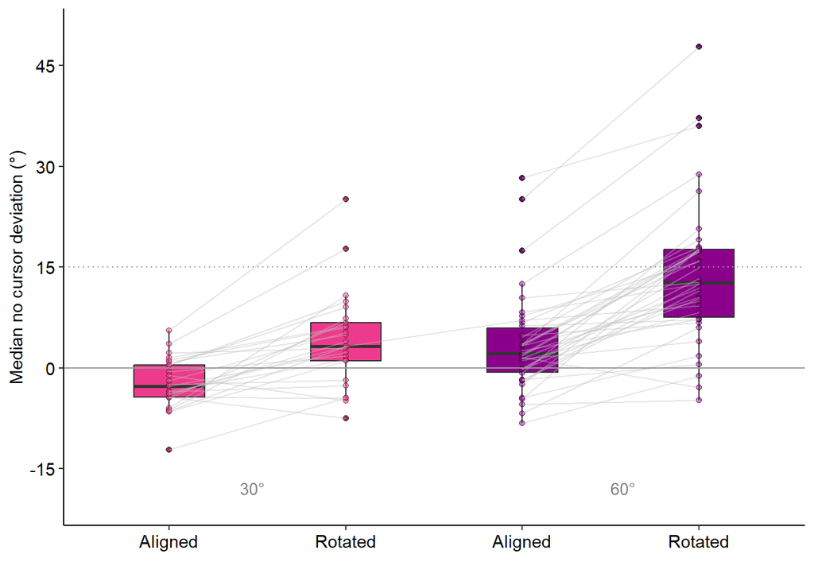

```r
filtered <- bind_rows(nocursor_30, nocursor_60)

# Define the order of no cursor types
nocursor_order <- c("aligned hand 30", "rotated hand 30", "aligned hand 60", "rotated hand 60")
# Use factor to set the order of bars on the plot
filtered <- filtered %>%
  mutate(nocursor_type = factor(nocursor_type, levels = nocursor_order))

hand_nocursor <- filtered %>%
  ggplot(aes(x=nocursor_type, y=nocursor_median, fill=nocursor_type))+
  geom_boxplot(width=0.4)+
  geom_point(aes(fill=nocursor_type),size=1.5,shape=21, alpha=0.5)+
  geom_line(aes(group=ppid), color='gray', alpha=0.4)+
  theme_classic()+
#Select custom bar colors
  scale_color_manual(values = c("aligned hand 30"="violetred2", "rotated hand 30"="violetred2", "aligned hand 60"="darkmagenta", "rotated hand 60"="darkmagenta", alpha = 0.9))+
  scale_fill_manual(values = c("aligned hand 30"="violetred2", "rotated hand 30"="violetred2", "aligned hand 60"="darkmagenta", "rotated hand 60"="darkmagenta", alpha = 0.9))+
#Adjust plot layout, font size, x and y axis
  theme(
    legend.position="none",
    axis.text = element_text(size = 11),
    axis.title.y = element_text(size = 11)
  ) +
  xlab("")+
  ylab("Median no cursor deviation (°)")+
  geom_hline(
    yintercept = c(0), linewidth = 0.4,
    colour = "#999999", linetype = "solid"
  ) +
  geom_hline(
    yintercept = c(15), linewidth = 0.4,
    colour = "#999999", linetype = "dotted"
  ) +
    scale_x_discrete(labels = c("aligned hand 30" = "Aligned", "aligned hand 60" = "Aligned",
                              "rotated hand 30" = "Rotated", "rotated hand 60" = "Rotated"))+
  scale_y_continuous(
    limits = c(-20, 50),
    breaks = c(0, -15, 15, 30, 45),
    labels = c(0, -15, 15, 30, 45)
  )+
  theme(text = element_text(size = 11))+
  theme(axis.text.x = element_text(color = "black"))+
  theme(axis.text.y = element_text(color = "black"))+
  annotate("text", x = 1.4, y = -17, hjust = 0, vjust = 1,
           label = "30°", color = "gray50", size = 3.5)+
  annotate("text", x = 3.5, y = -17, hjust = 0, vjust = 1,
           label = "60°", color = "gray50", size = 3.5)

print(hand_nocursor)
```

### t-test

Run paired t-tests to check for significance between no cursor reaches before and after training

```r
#Comparison stats
#paired t-test 30 degrees
naligned_group <- nocursor_30 %>%
  filter(nocursor_type == "aligned hand 30") %>%
  pull(nocursor_mean)

nrotated_group <- nocursor_30 %>%
  filter(nocursor_type == "rotated hand 30") %>%
  pull(nocursor_mean)

ndiffs_30 <- nrotated_group - naligned_group
t.test(ndiffs_30)
```

```
##
##  One Sample t-test
##
## data:  ndiffs_30
## t = 6.1786, df = 24, p-value = 2.2e-06
## alternative hypothesis: true mean is not equal to 0
## 95 percent confidence interval:
##  4.297475 8.608580
## sample estimates:
## mean of x
##  6.453027
```

```r
#paired t-test 60 degrees
naligned_group <- nocursor_60 %>%
  filter(nocursor_type == "aligned hand 60") %>%
  pull(nocursor_mean)

nrotated_group <- nocursor_60 %>%
  filter(nocursor_type == "rotated hand 60") %>%
  pull(nocursor_mean)

ndiffs_60 <- nrotated_group - naligned_group
t.test(ndiffs_60)
```

```
##
##  One Sample t-test
##
## data:  ndiffs_60
## t = 9.7276, df = 37, p-value = 9.688e-12
## alternative hypothesis: true mean is not equal to 0
## 95 percent confidence interval:
##   8.51370 12.99352
## sample estimates:
## mean of x
##  10.75361
```

## Pen (Experiment 2)

No Pen/ No Cursor Since aligned and rotated sessions were part of two jsons, start off by loading aligned sessions and create new dataframe

```r
#Load aligned session data and filter for only nocursor trials and exclude practice block
data_toola <- "pen_aligned.csv"
A_NoCursor_pen <- fread(data_toola)%>%
  filter(type=="nocursor", block_num >8)
#Create subtypes to differentiate between no cursor and no pen reaches before training
A_NoCursor_pen <- A_NoCursor_pen %>%
  mutate(nocursor_type = case_when(
    block_num %in% c(21,36,51) ~ "aligned pen",
    block_num %in% c(18,33,48) ~ "aligned hand",
    TRUE ~ "other"),
  nocursor_diff = case_when(
    nocursor_type == "aligned pen" ~ pen_final_angle - target_angle,
    nocursor_type == "aligned hand" ~ hand_final_angle - target_angle))
#Summary statistics
ANoCursor_summary <- A_NoCursor_pen %>%
  group_by(ppid,nocursor_type) %>%
  summarise(nocursor_median = median(nocursor_diff, na.rm = TRUE),
            nocursor_mean = mean(nocursor_diff, na.rm = TRUE),
            nocursor_sd = sd(nocursor_diff, na.rm = TRUE))
```

Load data from rotated session

```r
#Load rotated session data and filter for only nocursor trials and exclude practice block
data_penr <- "pen_rotated.csv"
Rnocursor_pen <- fread(data_penr)%>%
  filter(type=="nocursor")
#Create new subtypes and calculate angular reach deviation
Rnocursor_pen <- Rnocursor_pen %>%
  mutate(nocursor_type = case_when(
    block_num %in% c(15,30,45) ~ "rotated pen",
    block_num %in% c(12,27,42) ~ "rotated hand",
    block_num %in% c(50) ~ "rotated hand-pen"),
    nocursor_diff = case_when(
      nocursor_type == "rotated pen" ~ (pen_final_angle - target_angle)*(-1),
      nocursor_type == "rotated hand" ~ (hand_final_angle - target_angle)*(-1),
      nocursor_type == "rotated hand-pen" ~ (hand_final_angle - target_angle)*(-1)))
#Summary statistics
RNoCursor_summary <- Rnocursor_pen %>%
  group_by(ppid,nocursor_type) %>%
  summarise(nocursor_median = median(nocursor_diff),
            nocursor_mean = mean(nocursor_diff),
            nocursor_sd = sd(nocursor_diff))
```

Plot no cursor and no pen reaches with individual data

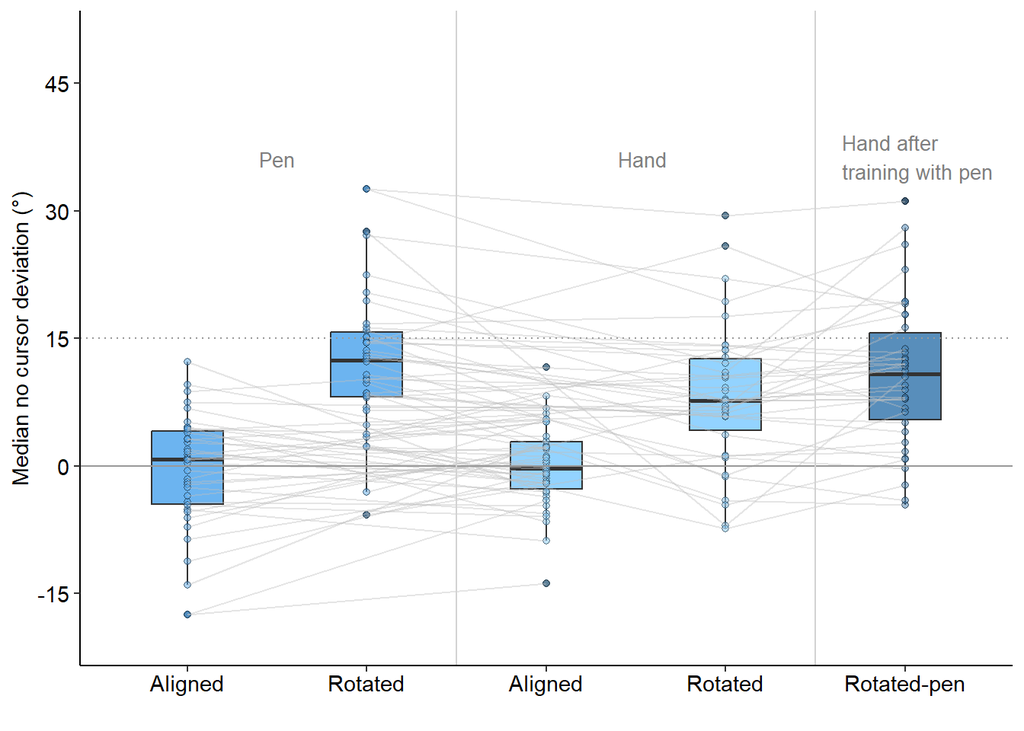

```r
#Combine aligned and rotated data
combined_dataset <- rbind(ANoCursor_summary, RNoCursor_summary)
#Reorder the order of bars displayed on the plot
order_of_bars <- c("aligned pen", "rotated pen", "aligned hand", "rotated hand", "rotated hand-pen")
combined_dataset$category <- factor(combined_dataset$nocursor_type, levels = order_of_bars)
#Assign custom colors to the bars
bar_colors <- c("skyblue1","steelblue2","skyblue1","steelblue","steelblue2")
#Plot using ggplot
Combine_nocursor <- combined_dataset %>%
  ggplot(aes(x=category, y=nocursor_median, fill=nocursor_type))+
  geom_boxplot(width = 0.4)+
  geom_point(aes(fill=category),size=1.5,shape=21, alpha=0.5)+
  geom_line(aes(group=ppid), color='gray', alpha=0.4)+
  scale_fill_manual(values = alpha(bar_colors, alpha=0.9))+
#Format plot by adding lines, adjusting font size, and x and y axis
  theme_classic()+
  geom_hline(
    yintercept = c(0), linewidth = 0.4,
    colour = "#999999", linetype = "solid"
  ) +
  geom_hline(
    yintercept = c(15), linewidth = 0.4,
    colour = "#999999", linetype = "dotted"
  ) +
  xlab("")+
  ylab("Median no cursor deviation (°)")+
  geom_vline(xintercept = c(2.5), color = "light gray", linetype = "solid", size = 0.5) +
  geom_vline(xintercept = c(4.5), color = "light gray", linetype = "solid", size = 0.5) +
  scale_x_discrete(labels=c('Aligned', 'Rotated', 'Aligned','Rotated', 'Rotated-pen'))+
  theme(
    legend.position="none",
    axis.text = element_text(size = 11),
    axis.title.y = element_text(size = 11)
  ) +
  theme(axis.text.x = element_blank())+
  scale_y_continuous(
    limits = c(-20, 50),
    breaks = c(0, -15, 15, 30, 45),
    labels = c(0, -15, 15, 30, 45)
  )+
  theme(text = element_text(size = 11))+
  theme(axis.text.x = element_text(color = "black"))+
  theme(axis.text.y = element_text(color = "black"))+
  annotate("text", x = 1.4, y = 37, hjust = 0, vjust = 1,
           label = "Pen", color = "gray50", size = 3.5)+
  annotate("text", x = 3.4, y = 37, hjust = 0, vjust = 1,
           label = "Hand", color = "gray50", size = 3.5)+
  annotate("text", x = 4.65, y = 39, hjust = 0, vjust = 1,
           label = "Hand after \ntraining with pen", color = "gray50", size = 3.5)
print(Combine_nocursor)
```

### t-test

Run paired t-tests between aligned and rotated to check for significance between the two types among the different groups

```r
#Comparison stats
#paired t-test
rotated_hand <- RNoCursor_summary %>%
  filter(nocursor_type == "rotated hand") %>%
  pull(nocursor_median)

rotated_pen <- RNoCursor_summary %>%
  filter(nocursor_type == "rotated pen") %>%
  pull(nocursor_median)

aligned_hand <- ANoCursor_summary %>%
  filter(nocursor_type == "aligned hand") %>%
  pull(nocursor_median)

aligned_pen <- ANoCursor_summary %>%
  filter(nocursor_type == "aligned pen") %>%
  pull(nocursor_median)

#t-test for hand no cursor in pen trials
diffs_hand <- rotated_hand - aligned_hand
t.test(diffs_hand)
```

```
##
##  One Sample t-test
##
## data:  diffs_hand
## t = 4.0911, df = 37, p-value = 0.0002228
## alternative hypothesis: true mean is not equal to 0
## 95 percent confidence interval:
##   4.133951 12.246654
## sample estimates:
## mean of x
##  8.190302
```

```r
#t-test for pen no cursor in pen trials
diffs_pen <- rotated_pen - aligned_pen
t.test(diffs_pen)
```

```
##
##  One Sample t-test
##
## data:  diffs_pen
## t = 6.0785, df = 37, p-value = 4.916e-07
## alternative hypothesis: true mean is not equal to 0
## 95 percent confidence interval:
##   8.735464 17.471118
## sample estimates:
## mean of x
##  13.10329
```

Now perform t-test between group differences to check for significance between groups

```r
#pen no cursor vs hand 30 degree
test <- diffs_pen - ndiffs_30
t.test(test)
```

```
##
##  One Sample t-test
##
## data:  test
## t = 3.0698, df = 37, p-value = 0.003999
## alternative hypothesis: true mean is not equal to 0
## 95 percent confidence interval:
##   2.25977 11.03483
## sample estimates:
## mean of x
##  6.647298
```

```r
#pen no cursor vs hand after training with pen
test <- diffs_pen - diffs_hand
t.test(test)
```

```
##
##  One Sample t-test
##
## data:  test
## t = 2.1261, df = 37, p-value = 0.04023
## alternative hypothesis: true mean is not equal to 0
## 95 percent confidence interval:
##  0.2307824 9.5951947
## sample estimates:
## mean of x
##  4.912989
```

```r
#hand after training with pen vs hand 30 degree
test <- diffs_hand - ndiffs_30
t.test(test)
```

```
##
##  One Sample t-test
##
## data:  test
## t = 0.75039, df = 37, p-value = 0.4578
## alternative hypothesis: true mean is not equal to 0
## 95 percent confidence interval:
##  -2.948635  6.417254
## sample estimates:
## mean of x
##  1.734309
```

# Localization

## Hand (Experiment 1)

### 30 degrees

```r
#filter for localization trials and exclude practice trials
localization_30 <- hand_30 %>%
  filter(type=="localization")%>%
  filter(!(trial_num >= 19 & trial_num <= 26))
#Create new subtype to differentiate between aligned and rotated trials
Localization_30 <- localization_30 %>%
  mutate(localization_type = case_when(
    trial_num < 191 ~ "aligned hand 30",
    trial_num > 194 ~ "rotated hand 30"))
#Calculate change in localization
local_arc_acqr <- Localization_30$localizing_angle - Localization_30$arc_aquired_angle
Localization_30$local_diff <- local_arc_acqr
#Summary statistics
localization_sum30 <- Localization_30 %>%
  group_by(ppid,localization_type) %>%
  summarise(local_median = median(local_diff, na.rm = TRUE),
            local_mean = mean(local_diff, na.rm = TRUE),
            local_sd = sd(local_diff, na.rm = TRUE))
```

### 60 degrees

```r
#filter for localization trials and exclude practice trials
localization_60 <- hand_60 %>%
  filter(type=="localization")%>%
  filter(!(trial_num >= 19 & trial_num <= 26))
#Create new subtype to differentiate between aligned and rotated trials
Localization_60 <- localization_60 %>%
  mutate(localization_type = case_when(
    trial_num < 191 ~ "aligned hand 60",
    trial_num > 194 ~ "rotated hand 60"))
#Calculate change in localization
local_arc_acqr <- Localization_60$localizing_angle - Localization_60$arc_aquired_angle
Localization_60$local_diff <- local_arc_acqr
#Summary statistics
localization_sum60 <- Localization_60 %>%
  group_by(ppid,localization_type) %>%
  summarise(local_median = median(local_diff, na.rm = TRUE),
            local_mean = mean(local_diff, na.rm = TRUE),
            local_sd = sd(local_diff, na.rm = TRUE))
```

Combine both 30 and 60 degree dataframes and plot hand localization

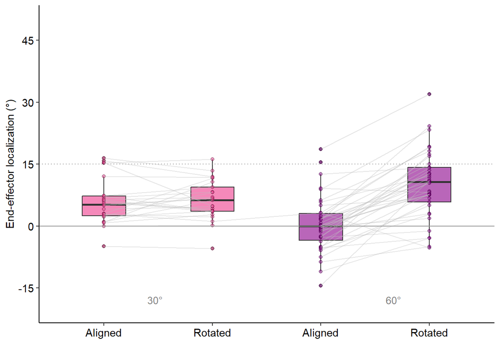

```r
filtered_data <- bind_rows(localization_sum30,localization_sum60)

# Define the order of localization types
localization_order <- c("aligned hand 30", "rotated hand 30", "aligned hand 60", "rotated hand 60")
# Use factor to set the order of bars on the plot
filtered_data <- filtered_data %>%
  mutate(localization_type = factor(localization_type, levels = localization_order))

hand_localization <- filtered_data %>%
  ggplot(aes(x=localization_type, y=local_median, fill=localization_type))+
  geom_boxplot(width=0.4, alpha = 0.6)+
  geom_point(aes(fill=localization_type),size=1.5,shape=21, alpha=0.5)+
  geom_line(aes(group=ppid), color='gray', alpha=0.4)+
  theme_classic()+
  scale_color_manual(values = c("aligned hand 30"="violetred2", "rotated hand 30"="violetred2", "aligned hand 60"="darkmagenta", "rotated hand 60"="darkmagenta", alpha = 0.9))+
  scale_fill_manual(values = c("aligned hand 30"="violetred2", "rotated hand 30"="violetred2", "aligned hand 60"="darkmagenta", "rotated hand 60"="darkmagenta", alpha = 0.9))+
  theme(
    legend.position="none",
    axis.text = element_text(size = 11),
    axis.title.y = element_text(size = 11)
  ) +
  xlab("")+
  ylab("End-effector localization (°)")+
  geom_hline(
    yintercept = c(0), linewidth = 0.4,
    colour = "#999999", linetype = "solid"
  ) +
  geom_hline(
    yintercept = c(15), linewidth = 0.4,
    colour = "#999999", linetype = "dotted"
  ) +
  scale_x_discrete(labels = c("aligned hand 30" = "Aligned", "aligned hand 60" = "Aligned",
                              "rotated hand 30" = "Rotated", "rotated hand 60" = "Rotated"))+
  scale_y_continuous(
    limits = c(-20, 50),
    breaks = c(0, -15, 15, 30, 45),
    labels = c(0, -15, 15, 30, 45)
  )+
  theme(text = element_text(size = 11))+
  theme(axis.text.x = element_text(color = "black"))+
  theme(axis.text.y = element_text(color = "black"))+
  annotate("text", x = 1.4, y = -17, hjust = 0, vjust = 1,
           label = "30°", color = "gray50", size = 3.5)+
  annotate("text", x = 3.6, y = -17, hjust = 0, vjust = 1,
           label = "60°", color = "gray50", size = 3.5)


print(hand_localization)
```

### t-test

Perform paired t-test to determine if there are significant changes in localization after training

```r
#Comparison stats
#paired t-test 30 degrees
aligned_group <- localization_sum30 %>%
  filter(localization_type == "aligned hand 30") %>%
  pull(local_median)

rotated_group <- localization_sum30 %>%
  filter(localization_type == "rotated hand 30") %>%
  pull(local_median)

diffs_30 <- rotated_group - aligned_group
t.test(diffs_30)
```

```
##
##  One Sample t-test
##
## data:  diffs_30
## t = 0.52665, df = 24, p-value = 0.6033
## alternative hypothesis: true mean is not equal to 0
## 95 percent confidence interval:
##  -1.269930  2.140072
## sample estimates:
## mean of x
## 0.4350712
```

```r
#paired t-test 60 degrees
aligned_group <- localization_sum60 %>%
  filter(localization_type == "aligned hand 60") %>%
  pull(local_median)

rotated_group <- localization_sum60 %>%
  filter(localization_type == "rotated hand 60") %>%
  pull(local_median)

diffs_60 <- rotated_group - aligned_group
t.test(diffs_60)
```

```
##
##  One Sample t-test
##
## data:  diffs_60
## t = 8.0908, df = 37, p-value = 1.053e-09
## alternative hypothesis: true mean is not equal to 0
## 95 percent confidence interval:
##   8.138899 13.577317
## sample estimates:
## mean of x
##  10.85811
```

## Pen (Experiment 2)

Pen and hand localization Aligned Session

```r
#Filter for only localization trials and exclude practice
data_toola <- read.csv("pen_aligned.csv")
Alocalization_pen <- data_toola %>%
  filter(type=="localization", block_num >8)
#Calculate change in localization
local_diff <- Alocalization_pen$localizing_angle - Alocalization_pen$arc_aquired_angle
Alocalization_pen$local_diff <- Alocalization_pen$localizing_angle - Alocalization_pen$arc_aquired_angle
#Create new subtype to differentiate pen and hand trials
Alocalization_pen <- Alocalization_pen %>%
    mutate(localization_type = case_when(
    block_num %in% c(9,13,24,28,39,43) ~ "aligned pen",
    block_num %in% c(11,15,26,30,41,45) ~ "aligned hand",
    TRUE ~ "other"
  ))
#Summary statistics
Alocalization_sum <- Alocalization_pen %>%
  group_by(ppid,localization_type) %>%
  summarise(local_median = median(local_diff, na.rm = TRUE),
            local_mean = mean(local_diff, na.rm = TRUE),
            local_sd = sd(local_diff, na.rm = TRUE))
```

Rotated session

```r
#Filter for localization trials
data_penr <- read.csv("pen_rotated.csv")
Rlocalization_pen <- data_penr %>%
  filter(type=="localization")
#Calculate change in localization
local_diff <- Rlocalization_pen$localizing_angle - Rlocalization_pen$arc_aquired_angle
Rlocalization_pen$local_diff <- Rlocalization_pen$localizing_angle - Rlocalization_pen$arc_aquired_angle
#Create subtype to differentiate between hand and pen trials
Rlocalization_pen <- Rlocalization_pen %>%
  mutate(localization_type = case_when(
    block_num %in% c(3,7,18,22,33,37) ~ "rotated pen",
    block_num %in% c(5,9,20,24,35,39) ~ "rotated hand",
    block_num %in% c(48) ~ "rotated pen hand",
    TRUE ~ "other"
  ))
#Summary statistics
Rlocalization_sum <- Rlocalization_pen %>%
  group_by(ppid,localization_type) %>%
  summarise(local_median = median(local_diff, na.rm = TRUE),
            local_mean = mean(local_diff, na.rm = TRUE),
            local_sd = sd(local_diff, na.rm = TRUE))
```

Combine both dataframes and plot Experiment 2 boxplots on one

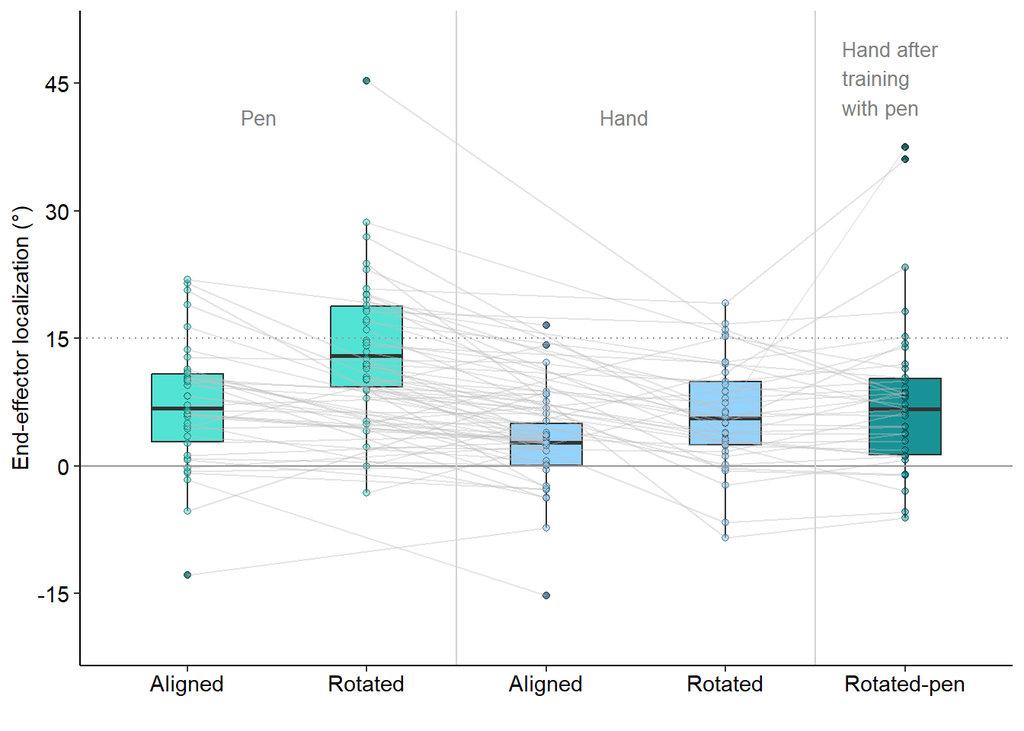

```r
combined_dataset <- rbind(Alocalization_sum, Rlocalization_sum)
order_of_bars <- c("aligned pen", "rotated pen", "aligned hand", "rotated hand", "rotated pen hand")
combined_dataset$category <- factor(combined_dataset$localization_type, levels = order_of_bars)

#Plot using ggplot and geom_boxplot
bar_colors <- c("skyblue1","turquoise","skyblue1","turquoise","turquoise4")
Combine_localization <- combined_dataset %>%
  ggplot(aes(x=category, y=local_median, fill=localization_type))+
  geom_boxplot(width=0.4)+
  geom_point(aes(fill=category),size=1.5,shape=21, alpha=0.5)+
  geom_line(aes(group=ppid), color='gray', alpha=0.4)+
  scale_fill_manual(values = alpha(bar_colors, alpha=0.9))+
  theme_classic()+
  geom_hline(
    yintercept = c(0), linewidth = 0.4,
    colour = "#999999", linetype = "solid"
  ) +
  geom_hline(
    yintercept = c(15), linewidth = 0.4,
    colour = "#999999", linetype = "dotted"
  ) +
  xlab("")+
  ylab("End-effector localization (°)")+
  geom_vline(xintercept = c(2.5), color = "light gray", linetype = "solid", size = 0.5) +
  geom_vline(xintercept = c(4.5), color = "light gray", linetype = "solid", size = 0.5) +
  scale_x_discrete(labels=c('Aligned', 'Rotated', 'Aligned','Rotated', 'Rotated-pen'))+
  theme(
    legend.position="none",
    axis.text = element_text(size = 11),
    axis.title.y = element_text(size = 11)
  ) +
  # theme(axis.ticks.x = element_blank())+
  theme(axis.text.x = element_blank())+
  scale_y_continuous(
    limits = c(-20, 50),
    breaks = c(0, -15, 15, 30, 45),
    labels = c(0, -15, 15, 30, 45)
  )+
  theme(text = element_text(size = 11))+
  theme(axis.text.x = element_text(color = "black"))+
  theme(axis.text.y = element_text(color = "black"))+
  annotate("text", x = 1.3, y = 42, hjust = 0, vjust = 1,
           label = "Pen", color = "gray50", size = 3.5)+
  annotate("text", x = 3.3, y = 42, hjust = 0, vjust = 1,
           label = "Hand", color = "gray50", size = 3.5)+
  annotate("text", x = 4.65, y = 50, hjust = 0, vjust = 1,
           label = "Hand after \ntraining \nwith pen", color = "gray50", size = 3.5)

print(Combine_localization)
```

### t-test

Perform paired t-test to determine if there are significant changes in localization before and after training

```r
#Comparison stats
#paired t-test
rotated_hand <- Rlocalization_sum %>%
  filter(localization_type == "rotated hand") %>%
  pull(local_median)

rotated_pen <- Rlocalization_sum %>%
  filter(localization_type == "rotated pen") %>%
  pull(local_median)

aligned_hand <- Alocalization_sum %>%
  filter(localization_type == "aligned hand") %>%
  pull(local_median)

aligned_pen <- Alocalization_sum %>%
  filter(localization_type == "aligned pen") %>%
  pull(local_median)

#t-test for hand localization in pen trials
diffs_hand <- rotated_hand - aligned_hand
t.test(diffs_hand)
```

```
##
##  One Sample t-test
##
## data:  diffs_hand
## t = 2.9634, df = 37, p-value = 0.005295
## alternative hypothesis: true mean is not equal to 0
## 95 percent confidence interval:
##  0.8785103 4.6771499
## sample estimates:
## mean of x
##   2.77783
```

```r
#t-test for pen localization in pen trials
diffs_pen <- rotated_pen - aligned_pen
t.test(diffs_pen)
```

```
##
##  One Sample t-test
##
## data:  diffs_pen
## t = 5.2691, df = 37, p-value = 6.126e-06
## alternative hypothesis: true mean is not equal to 0
## 95 percent confidence interval:
##  4.271222 9.608596
## sample estimates:
## mean of x
##  6.939909
```

Now perform t-test between the differences to check for significance between different groups

```r
#30 degree hand vs pen
test <- diffs_pen - diffs_hand
t.test(test)
```

```
##
##  One Sample t-test
##
## data:  test
## t = 3.8347, df = 37, p-value = 0.0004728
## alternative hypothesis: true mean is not equal to 0
## 95 percent confidence interval:
##  1.962913 6.361244
## sample estimates:
## mean of x
##  4.162079
```

```r
#pen vs hand after training with pen
test <- diffs_pen - diffs_30
t.test(test)
```

```
##
##  One Sample t-test
##
## data:  test
## t = 3.991, df = 37, p-value = 0.0002994
## alternative hypothesis: true mean is not equal to 0
## 95 percent confidence interval:
##  3.053851 9.352266
## sample estimates:
## mean of x
##  6.203059
```

```r
#30 degree hand vs hand after training with pen
test <- diffs_hand - diffs_30
t.test(test)
```

```
##
##  One Sample t-test
##
## data:  test
## t = 1.7897, df = 37, p-value = 0.08168
## alternative hypothesis: true mean is not equal to 0
## 95 percent confidence interval:
##  -0.2696446  4.3516041
## sample estimates:
## mean of x
##   2.04098
```

# ANOVAS

Our main analyses will consists of three groups: training the hand in Experiment 1, training the pen in Experiment 2, and training the hand after training the pen in Experiment 2

## Reach-to-Target

```r
#ANOVA for rotated hand (Exp 1), rotated pen(Exp2), rotated hand after training with pen (Exp2)
#Exp1 30 degrees rotated hand df for 3 trial sets (first, second, last)
hand_rot30 <- hand_30 %>%
  filter(type == 'rotated' & between(trial_num, 194, 293) & !(between(trial_num, 202, 289))) %>%
  mutate(ppid = as.character(as.integer(ppid)))%>%
  mutate(trial_set = case_when(
    between(trial_num, 194, 197) ~ "1",
    between(trial_num, 198, 201) ~ "2",
    between(trial_num, 290, 293) ~ "3",
    TRUE ~ NA_character_
  ))

#Exp1 60 degrees rotated hand df for 3 trial sets (first, second, last)
hand_rot60 <- hand_30 %>%
  filter(type == 'rotated' & between(trial_num, 194, 293) & !(between(trial_num, 202, 289))) %>%
  mutate(ppid = as.character(as.integer(ppid)))%>%
  mutate(trial_set = case_when(
    between(trial_num, 194, 197) ~ "1",
    between(trial_num, 198, 201) ~ "2",
    between(trial_num, 290, 293) ~ "3",
    TRUE ~ NA_character_
  ))

#Exp2 rotated pen
data_toolhand <- "pen_rotated.csv"
pen_rot <- fread(data_toolhand)
pen_rotated <- pen_rot %>%
  filter(between(trial_num, 2, 101) & !(between(trial_num, 10, 97))) %>%
  #mutate(ppid = as.character(as.integer(ppid)))%>%
  mutate(trial_set = case_when(
    between(trial_num, 2, 5) ~ "1",
    between(trial_num, 6, 9) ~ "2",
    between(trial_num, 98, 101) ~ "3",
    TRUE ~ NA_character_
  ),
  rotation = "30°")
pen_rotated <- pen_rotated %>%
  mutate(ppid = as.character(ppid))

#Exp2 rotated hand after training with pen
data_tool <- "pen_rotated.csv"
hand_trainpen <- fread(data_tool)
rotated_hand <- hand_trainpen %>%
  filter(type=='rotated'& between(trial_num, 391, 438) & !(between(trial_num, 399, 434))) %>%
  mutate(trial_set = case_when(
    between(trial_num, 391, 394) ~ "1",
    between(trial_num, 395, 398) ~ "2",
    between(trial_num, 435, 438) ~ "3",
    TRUE ~ NA_character_
  ),
  rotation = "30°")

#combine the 30 and 60 group with new variable 'rotation'
hand <- bind_rows(
  mutate(hand_rot30, rotation = "30°"),
  mutate(hand_rot60, rotation = "60°")
)

hand$group <- 'hand'
pen_rotated$group <- 'pen'
rotated_hand$group <- 'hand_pen'

#Bind df rows to create one dataframe consisting of all three groups
filtered_data <- bind_rows(hand, pen_rotated, rotated_hand)
#Summary statistics
sum_stats <- filtered_data %>%
  mutate(diff = ifelse(!is.na(cursor_3cm_out_angle), cursor_3cm_out_angle - target_angle)) %>%
  bind_rows(
    pen_rotated %>%  # Calculate diff for pen_rotated dataframe
      mutate(diff = ifelse(pen_present, pen_3cm_out_angle - target_angle)),
    rotated_hand %>%  # Calculate diff for rotated_hand dataframe
      mutate(diff = hand_3cm_out_angle - target_angle))%>%
  filter(abs(diff) < 90)%>%
  group_by(ppid, group, trial_set, rotation) %>%
  summarise(mean = mean(diff, na.rm = TRUE))
#Perform a 2x3x3 ANOVA
anova_result <- aov(mean ~ trial_set * group * rotation, data = sum_stats)
# Print the ANOVA summary
summary(anova_result)
```

```
##                     Df Sum Sq Mean Sq F value   Pr(>F)
## trial_set            2   7890    3945  87.298  < 2e-16 ***
## group                2  67918   33959 751.507  < 2e-16 ***
## rotation             1      0       0   0.000 1.000000
## trial_set:group      4   1081     270   5.983 0.000113 ***
## trial_set:rotation   2      0       0   0.000 1.000000
## Residuals          366  16539      45
## ---
## Signif. codes:  0 '***' 0.001 '**' 0.01 '*' 0.05 '.' 0.1 ' ' 1
```

```r
#Since trial_set:group interaction is significant, perform post-hoc Tukey test
tukey_results <- TukeyHSD(anova_result, which = "trial_set:group")
print(tukey_results)
```

```
##   Tukey multiple comparisons of means
##     95% family-wise confidence level
##
## Fit: aov(formula = mean ~ trial_set * group * rotation, data = sum_stats)
##
## $`trial_set:group`
##                              diff        lwr         upr     p adj
## 2:hand-1:hand          -9.2493620 -13.444641  -5.0540830 0.0000000
## 3:hand-1:hand         -15.7048630 -19.900142 -11.5095841 0.0000000
## 1:hand_pen-1:hand      -8.9484437 -13.462795  -4.4340920 0.0000001
## 2:hand_pen-1:hand     -13.4510100 -17.965362  -8.9366584 0.0000000
## 3:hand_pen-1:hand     -14.7374902 -19.251842 -10.2231386 0.0000000
## 1:pen-1:hand          -33.4514880 -37.965840 -28.9371364 0.0000000
## 2:pen-1:hand          -40.0234915 -44.537843 -35.5091398 0.0000000
## 3:pen-1:hand          -43.6687500 -48.183102 -39.1543984 0.0000000
## 3:hand-2:hand          -6.4555010 -10.650780  -2.2602221 0.0000798
## 1:hand_pen-2:hand       0.3009183  -4.213433   4.8152700 0.9999999
## 2:hand_pen-2:hand      -4.2016480  -8.716000   0.3127036 0.0910163
## 3:hand_pen-2:hand      -5.4881282 -10.002480  -0.9737766 0.0053934
## 1:pen-2:hand          -24.2021260 -28.716478 -19.6877744 0.0000000
## 2:pen-2:hand          -30.7741295 -35.288481 -26.2597778 0.0000000
## 3:pen-2:hand          -34.4193880 -38.933740 -29.9050364 0.0000000
## 1:hand_pen-3:hand       6.7564193   2.242068  11.2707710 0.0001457
## 2:hand_pen-3:hand       2.2538530  -2.260499   6.7682047 0.8267883
## 3:hand_pen-3:hand       0.9673728  -3.546979   5.4817245 0.9991184
## 1:pen-3:hand          -17.7466250 -22.260977 -13.2322733 0.0000000
## 2:pen-3:hand          -24.3186284 -28.832980 -19.8042768 0.0000000
## 3:pen-3:hand          -27.9638870 -32.478239 -23.4495353 0.0000000
## 2:hand_pen-1:hand_pen  -4.5025663  -9.314881   0.3097487 0.0874132
## 3:hand_pen-1:hand_pen  -5.7890465 -10.601362  -0.9767315 0.0062391
## 1:pen-1:hand_pen      -24.5030443 -29.315359 -19.6907293 0.0000000
## 2:pen-1:hand_pen      -31.0750478 -35.887363 -26.2627327 0.0000000
## 3:pen-1:hand_pen      -34.7203063 -39.532621 -29.9079913 0.0000000
## 3:hand_pen-2:hand_pen  -1.2864802  -6.098795   3.5258348 0.9957601
## 1:pen-2:hand_pen      -20.0004780 -24.812793 -15.1881630 0.0000000
## 2:pen-2:hand_pen      -26.5724815 -31.384796 -21.7601664 0.0000000
## 3:pen-2:hand_pen      -30.2177400 -35.030055 -25.4054250 0.0000000
## 1:pen-3:hand_pen      -18.7139978 -23.526313 -13.9016828 0.0000000
## 2:pen-3:hand_pen      -25.2860013 -30.098316 -20.4736862 0.0000000
## 3:pen-3:hand_pen      -28.9312598 -33.743575 -24.1189448 0.0000000
## 2:pen-1:pen            -6.5720035 -11.384318  -1.7596884 0.0008603
## 3:pen-1:pen           -10.2172620 -15.029577  -5.4049470 0.0000000
## 3:pen-2:pen            -3.6452586  -8.457574   1.1670565 0.3073354
```

## No Cursor/ No Pen

Experiment 1 - 30 degrees hand no cursor

```r
#30 degrees
#filter the hand no cursors and create new cursor type and type
hand_nocur30 <- hand_30 %>%
  filter(type=="nocursor", block_num >7)%>%
  mutate(
    type = case_when(
      trial_num <= 191 ~ "aligned",
      trial_num >= 343 ~ "rotated"
    ),
    group = "hand 30",
    ppid = as.character(as.integer(ppid)),
    deviation = hand_final_angle - target_angle
  )

# Summary statistics
hand30 <- hand_nocur30 %>%
  group_by(ppid,type, group) %>%
  summarise(
    median = median(deviation, na.rm = TRUE),
    mean = mean(deviation, na.rm = TRUE),
    sd = sd(deviation, na.rm = TRUE)
  )
```

Experiment 1 - 60 degrees hand no cursor

```r
#60 degrees
#filter the hand no cursors and create new cursor type and type
hand_nocur60 <- hand_60 %>%
  filter(type=="nocursor", block_num >7)%>%
  mutate(
    type = case_when(
      trial_num <= 191 ~ "aligned",
      trial_num >= 343 ~ "rotated"
    ),
    group = "hand 60",
    ppid = as.character(as.integer(ppid)),
    deviation = hand_final_angle - target_angle
  )

#Summary statistics
hand60 <- hand_nocur60 %>%
  group_by(ppid,type, group) %>%
  summarise(median = median(deviation, na.rm = TRUE),
            mean = mean(deviation, na.rm = TRUE),
            sd = sd(deviation, na.rm = TRUE))
```

Experiment 2 - Pen aligned and rotated

```r
pen_aligned <- read.csv("pen_aligned.csv")
pen_rotated <- read.csv("pen_rotated.csv")
# Filter and add a "type" variable based on block numbers
aligned <- pen_aligned %>%
  filter(block_num %in% c(21, 36, 51)) %>%
  mutate(
    type = "aligned",
    group = "pen",
    deviation = pen_final_angle - target_angle)

rotated <- pen_rotated %>%
  filter(block_num %in% c(15, 30, 45)) %>%
  mutate(
    type = "rotated",
    group = "pen",
    deviation = pen_final_angle - target_angle)
#combine both dfs
pen_comb <- bind_rows(aligned, rotated)

#Summary statistics
pen <- pen_comb %>%
  group_by(ppid,type, group) %>%
  summarise(median = median(deviation, na.rm = TRUE),
            mean = mean(deviation, na.rm = TRUE),
            sd = sd(deviation, na.rm = TRUE))
```

Experiment 2 - Hand after training with pen

```r
aligned_hp <- pen_aligned %>%
  filter(block_num %in% c(18,33,48))%>%
  mutate(
    type = "aligned",
    group = "hand_pen",
    deviation = hand_final_angle - target_angle)

rotated_hp <- pen_rotated %>%
  filter(block_num %in% c(50))%>%
  mutate(
    type = "rotated",
    group = "hand_pen",
    deviation = hand_final_angle - target_angle)
#combine both dfs
handpen <- bind_rows(aligned_hp, rotated_hp)

#Summary statistics
hand_pen <- handpen %>%
  group_by(ppid,type, group) %>%
  summarise(median = median(deviation, na.rm = TRUE),
            mean = mean(deviation, na.rm = TRUE),
            sd = sd(deviation, na.rm = TRUE))
```

Combine hand, pen, and hand after pen data frames and then perform 2x4 ANOVA

```r
#Combine the dataframe into one
nocursor <- bind_rows(hand30,hand60,pen,hand_pen)
nocursor <- nocursor %>%
  mutate(trial_type = "no cursor")

#Perform 2x4 ANOVA
anova_result <- aov(mean ~ type * group, data = nocursor)
# Summarize the ANOVA results
summary(anova_result)
```

```
##              Df Sum Sq Mean Sq F value   Pr(>F)
## type          1   7481    7481 119.920  < 2e-16 ***
## group         3   2231     744  11.921 2.35e-07 ***
## type:group    3    247      82   1.319    0.268
## Residuals   270  16843      62
## ---
## Signif. codes:  0 '***' 0.001 '**' 0.01 '*' 0.05 '.' 0.1 ' ' 1
```

```r
tukey_results <- TukeyHSD(anova_result, which = "type:group")
print(tukey_results)
```

```
##   Tukey multiple comparisons of means
##     95% family-wise confidence level
##
## Fit: aov(formula = mean ~ type * group, data = nocursor)
##
## $`type:group`
##                                           diff        lwr         upr     p adj
## rotated:hand 30-aligned:hand 30    -6.45302723 -13.277382   0.3713271 0.0789340
## aligned:hand 60-aligned:hand 30    -6.43804334 -12.651382  -0.2247044 0.0362375
## rotated:hand 60-aligned:hand 30   -17.19165259 -23.404992 -10.9783137 0.0000000
## aligned:hand_pen-aligned:hand 30   -2.60751058  -8.820850   3.6058284 0.9048918
## rotated:hand_pen-aligned:hand 30  -13.68852467 -19.901864  -7.4751857 0.0000000
## aligned:pen-aligned:hand 30        -2.61874583  -8.832085   3.5945931 0.9029007
## rotated:pen-aligned:hand 30       -14.48838989 -20.701729  -8.2750510 0.0000000
## aligned:hand 60-rotated:hand 30     0.01498389  -6.198355   6.2283228 1.0000000
## rotated:hand 60-rotated:hand 30   -10.73862536 -16.951964  -4.5252864 0.0000073
## aligned:hand_pen-rotated:hand 30    3.84551665  -2.367822  10.0588556 0.5585180
## rotated:hand_pen-rotated:hand 30   -7.23549744 -13.448836  -1.0221585 0.0103356
## aligned:pen-rotated:hand 30         3.83428140  -2.379058  10.0476203 0.5623168
## rotated:pen-rotated:hand 30        -8.03536265 -14.248702  -1.8220237 0.0024962
## rotated:hand 60-aligned:hand 60   -10.75360925 -16.288892  -5.2183270 0.0000003
## aligned:hand_pen-aligned:hand 60    3.83053276  -1.704750   9.3658150 0.4085382
## rotated:hand_pen-aligned:hand 60   -7.25048133 -12.785764  -1.7151991 0.0020549
## aligned:pen-aligned:hand 60         3.81929751  -1.715985   9.3545798 0.4125190
## rotated:pen-aligned:hand 60        -8.05034655 -13.585629  -2.5150643 0.0003427
## aligned:hand_pen-rotated:hand 60   14.58414201   9.048860  20.1194243 0.0000000
## rotated:hand_pen-rotated:hand 60    3.50312792  -2.032154   9.0384102 0.5292198
## aligned:pen-rotated:hand 60        14.57290676   9.037624  20.1081890 0.0000000
## rotated:pen-rotated:hand 60         2.70326270  -2.832020   8.2385450 0.8113232
## rotated:hand_pen-aligned:hand_pen -11.08101409 -16.616296  -5.5457318 0.0000001
## aligned:pen-aligned:hand_pen       -0.01123525  -5.546518   5.5240470 1.0000000
## rotated:pen-aligned:hand_pen      -11.88087930 -17.416162  -6.3455970 0.0000000
## aligned:pen-rotated:hand_pen       11.06977884   5.534497  16.6050611 0.0000001
## rotated:pen-rotated:hand_pen       -0.79986522  -6.335147   4.7354171 0.9998498
## rotated:pen-aligned:pen           -11.86964405 -17.404926  -6.3343618 0.0000000
```

## Localization

Experiment 1 - 30 degrees hand localization

```r
#30 degrees
#filter the hand localizations and create new type
local_30 <- hand_30 %>%
  filter(type=="localization", block_num >8)%>%
  mutate(
    type = case_when(
    trial_num < 191 ~ "aligned",
    trial_num > 194 ~ "rotated"),
  ppid = as.character(as.integer(ppid)),
  group = "hand 30",
  deviation = localizing_angle - arc_aquired_angle)
#Summary statistics
local30_sum <- local_30 %>%
  group_by(ppid, type, group) %>%
  summarise(median = median(deviation, na.rm = TRUE),
            mean = mean(deviation, na.rm = TRUE),
            sd = sd(deviation, na.rm = TRUE))
```

Experiment 1 - 60 degrees hand localization

```r
#60 degrees
#filter the hand localizations and create new type
local_60 <- hand_60 %>%
  filter(type=="localization", block_num >8)%>%
  mutate(
    type = case_when(
    trial_num < 191 ~ "aligned",
    trial_num > 194 ~ "rotated"),
  ppid = as.character(as.integer(ppid)),
  group = "hand 60",
  deviation = localizing_angle - arc_aquired_angle)
#Summary statistics
local60_sum <- local_60 %>%
  group_by(ppid, type, group) %>%
  summarise(median = median(deviation, na.rm = TRUE),
            mean = mean(deviation, na.rm = TRUE),
            sd = sd(deviation, na.rm = TRUE))
```

Experiment 2 - Pen localization

```r
#Pen aligned
# Filter and add a "type" variable based on block numbers
a_local <- pen_aligned %>%
  filter(block_num %in% c(9,13,24,28,39,43)) %>%
  mutate(
    type = "aligned",
    group = "pen",
    deviation = localizing_angle - arc_aquired_angle)

r_local <- pen_rotated %>%
  filter(block_num %in% c(3,7,18,22,33,37)) %>%
  mutate(
    type = "rotated",
    group = "pen",
    deviation = localizing_angle - arc_aquired_angle)
#combine both dfs
pen_comb <- bind_rows(a_local, r_local)
#Summary statistics
local_pen <- pen_comb %>%
  group_by(ppid, type, group) %>%
  summarise(median = median(deviation, na.rm = TRUE),
            mean = mean(deviation, na.rm = TRUE),
            sd = sd(deviation, na.rm = TRUE))
```

Experiment 2 - Hand after training with pen

```r
alocal_hp <- pen_aligned %>%
  filter(block_num %in% c(11,15,26,30,41,45))%>%
  mutate(
    type = "aligned",
    group = "hand_pen",
    deviation = localizing_angle - arc_aquired_angle)

rlocal_hp <- pen_rotated %>%
  filter(block_num %in% c(48))%>%
  mutate(
    type = "rotated",
    group = "hand_pen",
    deviation = localizing_angle - arc_aquired_angle)

#combine both dfs
handpen <- bind_rows(alocal_hp, rlocal_hp)
#Summary statistics
local_handpen <- handpen %>%
  group_by(ppid, type, group) %>%
  summarise(median = median(deviation, na.rm = TRUE),
            mean = mean(deviation, na.rm = TRUE),
            sd = sd(deviation, na.rm = TRUE))
```

Combine all four dataframes and perform 2x4 ANOVA

```r
localization <- bind_rows(local30_sum,local60_sum,local_pen,local_handpen)
localization <- localization %>%
  mutate(trial_type = "localization")

#Perform 2x4 ANOVA
anova_localization <- aov(mean ~ type * group, data = localization)
# Summarize the ANOVA results
summary(anova_localization)
```

```
##              Df Sum Sq Mean Sq F value   Pr(>F)
## type          1   3003  3003.3  52.181 5.17e-12 ***
## group         3   1264   421.3   7.319 9.80e-05 ***
## type:group    3    771   257.1   4.467  0.00442 **
## Residuals   270  15540    57.6
## ---
## Signif. codes:  0 '***' 0.001 '**' 0.01 '*' 0.05 '.' 0.1 ' ' 1
```

```r
#type:group interaction is significant, so perform post-hoc Tukey test
tukey_results <- TukeyHSD(anova_localization, which = "type:group")
print(tukey_results)
```

```
##   Tukey multiple comparisons of means
##     95% family-wise confidence level
##
## Fit: aov(formula = mean ~ type * group, data = localization)
##
## $`type:group`
##                                          diff          lwr        upr     p adj
## rotated:hand 30-aligned:hand 30    1.09571754  -5.45934711  7.6507822 0.9996034
## aligned:hand 60-aligned:hand 30   -5.27936278 -11.24752279  0.6887972 0.1263543
## rotated:hand 60-aligned:hand 30    5.62916056  -0.33899945 11.5973206 0.0804694
## aligned:hand_pen-aligned:hand 30  -3.23795951  -9.20611952  2.7302005 0.7146339
## rotated:hand_pen-aligned:hand 30   2.02310699  -3.94505303  7.9912670 0.9686099
## aligned:pen-aligned:hand 30        1.09280298  -4.87535703  7.0609630 0.9992775
## rotated:pen-aligned:hand 30        8.24791501   2.27975500 14.2160750 0.0008593
## aligned:hand 60-rotated:hand 30   -6.37508032 -12.34324033 -0.4069203 0.0269290
## rotated:hand 60-rotated:hand 30    4.53344301  -1.43471700 10.5016030 0.2863211
## aligned:hand_pen-rotated:hand 30  -4.33367705 -10.30183706  1.6344830 0.3441358
## rotated:hand_pen-rotated:hand 30   0.92738944  -5.04077057  6.8955495 0.9997558
## aligned:pen-rotated:hand 30       -0.00291456  -5.97107457  5.9652455 1.0000000
## rotated:pen-rotated:hand 30        7.15219747   1.18403746 13.1203575 0.0072194
## rotated:hand 60-aligned:hand 60   10.90852333   5.59166381 16.2253829 0.0000000
## aligned:hand_pen-aligned:hand 60   2.04140327  -3.27545625  7.3582628 0.9389735
## rotated:hand_pen-aligned:hand 60   7.30246976   1.98561024 12.6193293 0.0009548
## aligned:pen-aligned:hand 60        6.37216576   1.05530624 11.6890253 0.0072124
## rotated:pen-aligned:hand 60       13.52727779   8.21041827 18.8441373 0.0000000
## aligned:hand_pen-rotated:hand 60  -8.86712007 -14.18397959 -3.5502605 0.0000180
## rotated:hand_pen-rotated:hand 60  -3.60605357  -8.92291309  1.7108060 0.4358657
## aligned:pen-rotated:hand 60       -4.53635757  -9.85321709  0.7805019 0.1581277
## rotated:pen-rotated:hand 60        2.61875446  -2.69810506  7.9356140 0.8045201
## rotated:hand_pen-aligned:hand_pen  5.26106650  -0.05579303 10.5779260 0.0547463
## aligned:pen-aligned:hand_pen       4.33076249  -0.98609703  9.6476220 0.2049132
## rotated:pen-aligned:hand_pen      11.48587452   6.16901500 16.8027340 0.0000000
## aligned:pen-rotated:hand_pen      -0.93030400  -6.24716352  4.3865555 0.9994637
## rotated:pen-rotated:hand_pen       6.22480803   0.90794851 11.5416675 0.0096810
## rotated:pen-aligned:pen            7.15511203   1.83825251 12.4719716 0.0013392
```

# Localization & No Cursor relationship

```r
combined_dat <- bind_rows(localization, nocursor)%>%
  filter(type == 'rotated')

combine <- combined_dat %>%
  mutate(
    localization = ifelse(trial_type == "localization", mean, NA),
    nocursor = ifelse(trial_type == "no cursor", mean * -1, NA)
  )

df <- combine %>%
  group_by(ppid,group) %>%
  summarise(
    localization = mean(localization, na.rm = TRUE),
    nocursor = mean(nocursor, na.rm = TRUE)
  )
```

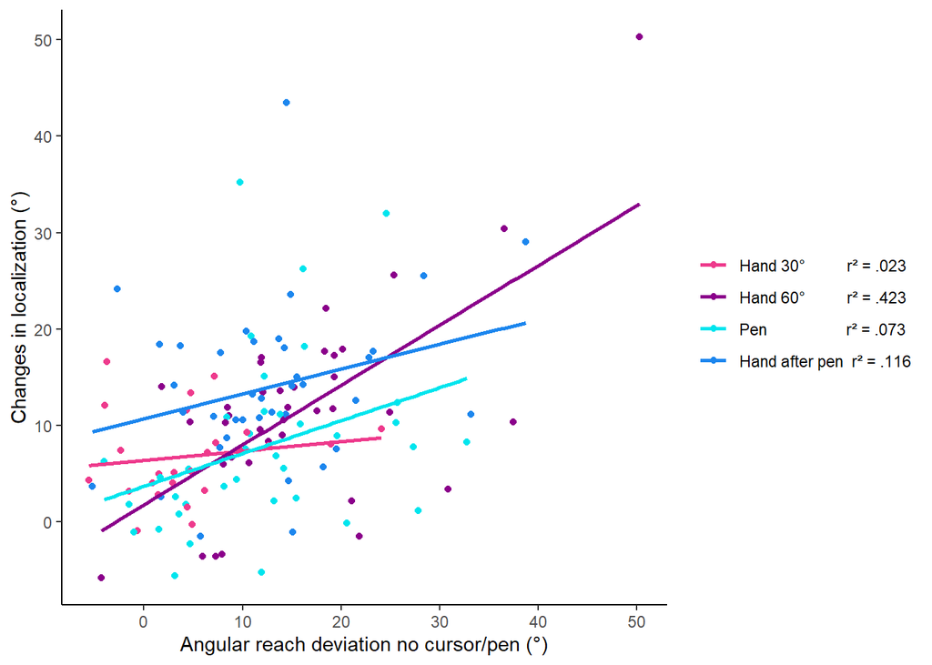

```r
# Plot
custom_colors <- c("hand 30" = "violetred2", "hand 60" = "darkmagenta", "hand_pen" = "turquoise2", "pen" = "dodgerblue2")
custom_labels <- c("hand 30" = "Hand 30°          r² = .023", "hand 60" = "Hand 60°          r² = .423", "hand_pen" = "Hand after pen   r² = .116", "pen" = "Pen                   r² = .073")
custom_labels <- c("Hand 30°          r² = .023", "Hand 60°          r² = .423", "Pen                   r² = .073", "Hand after pen  r² = .116")

ggplot(df, aes(x = nocursor, y = localization, color = group)) +
  geom_point() + # Scatterplot
  geom_smooth(method = "lm", se = FALSE) + # Add regression line
  labs(x = "Angular reach deviation no cursor/pen (°)", y = "Changes in localization (°)", color = NULL) + # Axis and legend labels
  scale_color_manual(values = custom_colors, labels = custom_labels)+
  theme_classic() +
  #theme(legend.position = "none") +
  theme(text = element_text(size = 11))
```

```r
  #theme(
    #legend.position = c(1.0, 1.05), # Adjust legend position
   # legend.justification = c(1, 1) # Justify legend to top right
 # )
```

Fit regression model

```r
# Fit linear regression model with group variable
lm_model <- lm(localization ~ nocursor + group, data = df)

# Print regression model summary
summary(lm_model)
```

```
##
## Call:
## lm(formula = localization ~ nocursor + group, data = df)
##
## Residuals:
##      Min       1Q   Median       3Q      Max
## -15.9990  -3.6030  -0.8346   3.7942  28.7703
##
## Coefficients:
##               Estimate Std. Error t value Pr(>|t|)
## (Intercept)    4.96912    1.60094   3.104  0.00233 **
## nocursor       0.39926    0.07347   5.435 2.51e-07 ***
## grouphand 60   0.24592    2.16138   0.114  0.90958
## grouphand_pen -1.96147    2.08128  -0.942  0.34767
## grouppen       3.94398    2.09706   1.881  0.06218 .
## ---
## Signif. codes:  0 '***' 0.001 '**' 0.01 '*' 0.05 '.' 0.1 ' ' 1
##
## Residual standard error: 7.814 on 134 degrees of freedom
## Multiple R-squared:  0.2622, Adjusted R-squared:  0.2402
## F-statistic: 11.91 on 4 and 134 DF,  p-value: 2.625e-08
```